# spherepc: An R Package for Dimension Reduction on a Sphere

## Principal circle

In a spherical surface, as shown in Figure 1, the principal geodesic analysis always results in a great circle, which cannot be sufficient to identify the non-geodesic structure of data. The circle on a sphere that minimizes a reconstruction error is called a principal circle, where the reconstruction error is defined as the total sum of squares of geodesic distances between the circle and data points. However, the existing method for generating the principal circle is still based on the tangent space approximation and its inverse process, thereby leading to numerical errors. Lee, Kim, and Oh (2021a) have proposed an exact principal circle in an intrinsic way and its practical algorithm based on gradient descent. The details are described in Section 3 of Kim, Lee, and Oh (2020) and Appendix B of Lee, Kim, and Oh (2021b). The [*spherepc*](https://CRAN.R-project.org/package=spherepc) package provides the `PrincipalCircle()` function to implement the intrinsic principal circle. Its usage is followed by

```r
     PrincipalCircle(data, step.size = 1e-3, thres = 1e-5, maxit = 10000).
```

Table 3: Arguments of the `PrincipalCircle()`.

| Argument | Description |
| --- | --- |
| `data` | matrix or data frame consisting of spatial locations (longitude and latitude denoted by degrees) with two columns. |
| `step.size` | step size of gradient descent algorithm. For convergence of the algorithm, `step.size` is recommended to be below 0.01. The default is 1e-3. |
| `thres` | threshold of the stopping condition. The default is 1e-5. |
| `maxit` | maximum number of iterations. The default is 10000. |

The arguments of the `PrincipalCircle()` are described in Table 3, and its output is a three-dimensional vector, where the first and second components are longitude and latitude (represented by degrees), respectively. The last one is the radius of the principal circle. To display the circle, the `GenerateCircle()` function should be implemented. Its usage is followed by

```r
    GenerateCircle(center, radius, T = 1000).
```

The output of the `GenerateCircle()` function is a matrix consisting of spatial locations (longitude and latitude by degrees) with two columns, which can be plotted by the `sphereplot::rgl.sphgrid()` and `sphereplot::rgl.sphpoints()` functions from the [*sphereplot*](https://CRAN.R-project.org/package=sphereplot) package (Robotham 2013). Note that the [*sphereplot*](https://CRAN.R-project.org/package=sphereplot) package depends on the [*rgl*](https://CRAN.R-project.org/package=rgl) package (Adler and Murdoch 2020). The detailed arguments of the `GenerateCircle()` function are described in Table 4.

Table 4: Arguments of the `GenerateCircle()`.

| Argument | Description |
| --- | --- |
| `center` | center of circle with spatial locations (longitude and latitude denoted by degrees). |
| `radius` | radius of circle. It should be range from 0 to $\pi$. |
| `T` | the number of points that make up a circle. The points in a circle are equally spaced. The default is 1000. |

The following codes implement principal circles by the `PrincipalCircle()` and `GenerateCircle()` functions.

```r
   ## for all the following examples, longitude and latitude are denoted by degrees
   #### example 1: half-great circle data
   > circle <- GenerateCircle(c(150, 60), radius = pi/2, T = 1000)
   > half.great.circle <- circle[circle[, 1] < 0, , drop = FALSE]
   > sigma <- 2                           # noise level
   > half.great.circle <- half.great.circle + sigma * rnorm(nrow(half.great.circle))
   ## find a principal circle
   > PC <- PrincipalCircle(half.great.circle)
   > result <- GenerateCircle(PC[1:2], PC[3], T = 1000)
   ## plot the half-great circle data and principal circle
   > sphereplot::rgl.sphgrid(col.lat = "black", col.long = "black")
   > sphereplot::rgl.sphpoints(half.great.circle, radius = 1, col = "blue", size = 9)
   > sphereplot::rgl.sphpoints(result, radius = 1, col = "red", size = 6)

   #### example 2: circular data
   > n <- 700                             # the number of samples
   > sigma <- 5                           # noise level
   > x <- seq(-180, 180, length.out = n)
   > y <- 45 + sigma * rnorm(n)
   > simul.circle <- cbind(x, y)
   ## find a principal circle
   > PC <- PrincipalCircle(simul.circle)
   > result <- GenerateCircle(PC[1:2], PC[3], T = 1000)
   ## plot the circular data and principal circle
   > sphereplot::rgl.sphgrid(col.lat = "black", col.long = "black")
   > sphereplot::rgl.sphpoints(simul.circle, radius = 1, col = "blue", size = 9)
   > sphereplot::rgl.sphpoints(result, radius = 1, col = "red", size = 6)
```

The results of the principal circle are shown in Figure 2. As one can see, the principal circle identifies the circular patterns of the noisy half-great circle and circular dataset well.

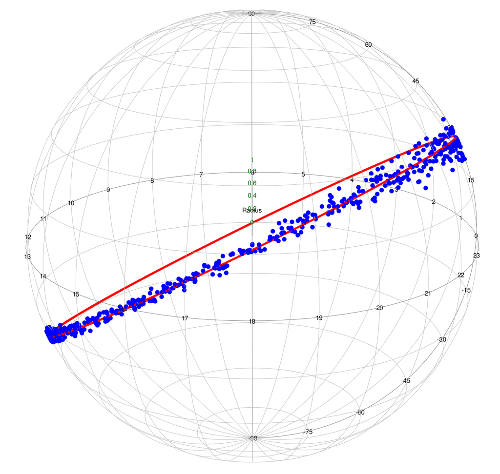

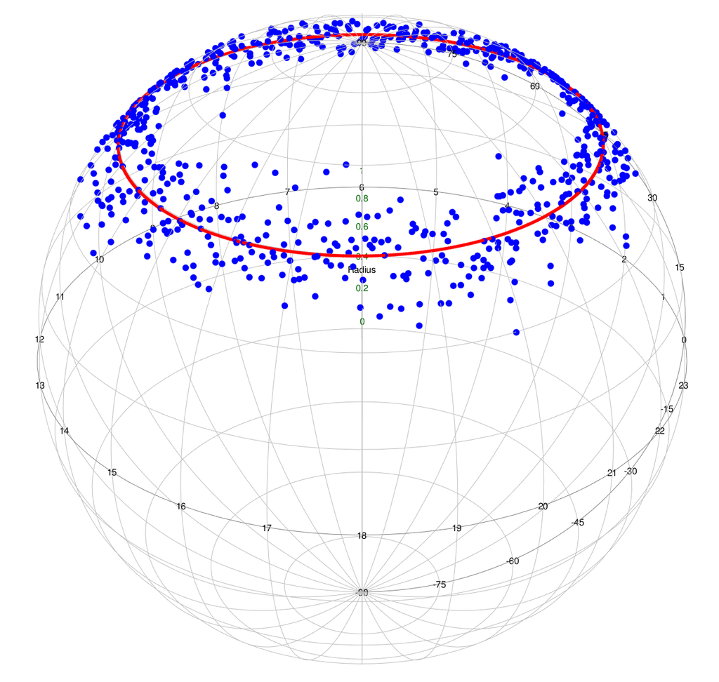

Figure 2: Half-great circle data and circular data (blue) and the results (red) of the principal circle from left to right. The principal circle can identify the relatively small circular structure (right) and the great circle structure (left).

# Spherical principal curves

Principal curves proposed by Hastie and Stuetzle (1989) can be considered as a nonlinear generalization of the principal component analysis in the sense that the principal curves pass through the middle of given data and reserve a stationary property. The curve is a smooth function from a one-dimensional closed interval to a given space; then, a curve $f$ is said to be a principal curve of $X$ or self-consistent if the curve satisfies
$$f(\lambda) = \mathbb{E}\big(X \ |
\ \lambda_{f}(X)=\lambda\big),$$
where $f(\lambda_f(x))$ is the closest (projection) point in the curve $f$ from the point $x$.

Hauberg (2016) provided an algorithm for principal curves on Riemannian manifolds. However, Hauberg (2016) used approximations for finding the closest point of each data point, which may lead to numerical errors. Recently, Lee, Kim, and Oh (2021a) presented theoretical results of principal curves on spheres and a practical algorithm for constructing principal curves without any approximations, called spherical principal curves (SPC), thereby causing the given data to be represented more precisely and smoothly compared to principal curves of Hauberg (2016). In the both ways of extrinsic and intrinsic approaches, the method of SPC updates curves on the spherical surfaces to represent the given data and fits curves that satisfy the stationary conditions. For more details, refer to Kim, Lee, and Oh (2020) or Lee, Kim, and Oh (2021a).

The package [*spherepc*](https://CRAN.R-project.org/package=spherepc) provides the `SPC()` function for implementing spherical principal curves and the `SPC.Hauberg()` function for principal curves of Hauberg (2016). The usage of the `SPC()` function is as follows.

```r
    SPC(data, q = 0.05, T = nrow(data), step.size = 1e-3, maxit = 30,
        type = "Intrinsic", thres = 1e-2, deletePoints = FALSE,
        plot.proj = FALSE, kernel = "quartic", col1 = "blue",
        col2 = "green", col3 = "red").
```

```r
   #### longitude and latitude are expressed in degrees
   #### example: waveform data
   > n <- 200
   > alpha <- 1/3; freq <- 4                    # amplitude and frequency of wave
   > sigma1 <- 2; sigma2 <- 10                  # noise levels
   > lon <- seq(-180, 180, length.out = n)      # uniformly sampled longitude
   > lat <- alpha * 180/pi * sin(freq * lon * pi/180) + 10      # latitude vector
   ## add Gaussian noises on the latitude vector
   > lat1 <- lat + sigma1 * rnorm(length(lon))
   > lat2 <- lat + sigma2 * rnorm(length(lon))
   > wave1 <- cbind(lon, lat1); wave2 <- cbind(lon, lat2)
   ## implement Hauberg's principal curves to the waveform data
   > SPC.Hauberg(wave1, q = 0.05)
   ## implement SPC to the (noisy) waveform data
   > SPC(wave1, q = 0.05)
   > SPC(wave2, q = 0.05)
```

The above codes generate the results in Figure 3. As one can see, the `SPC()` and `SPC.Hauberg()` functions identify the waveform pattern of the simulated data. Especially, the `SPC()` generates a smoother curve. The detailed arguments and outputs of the `SPC()` are described in Tables 5 and 6, respectively, which are the same for the `SPC.Hauberg()`.

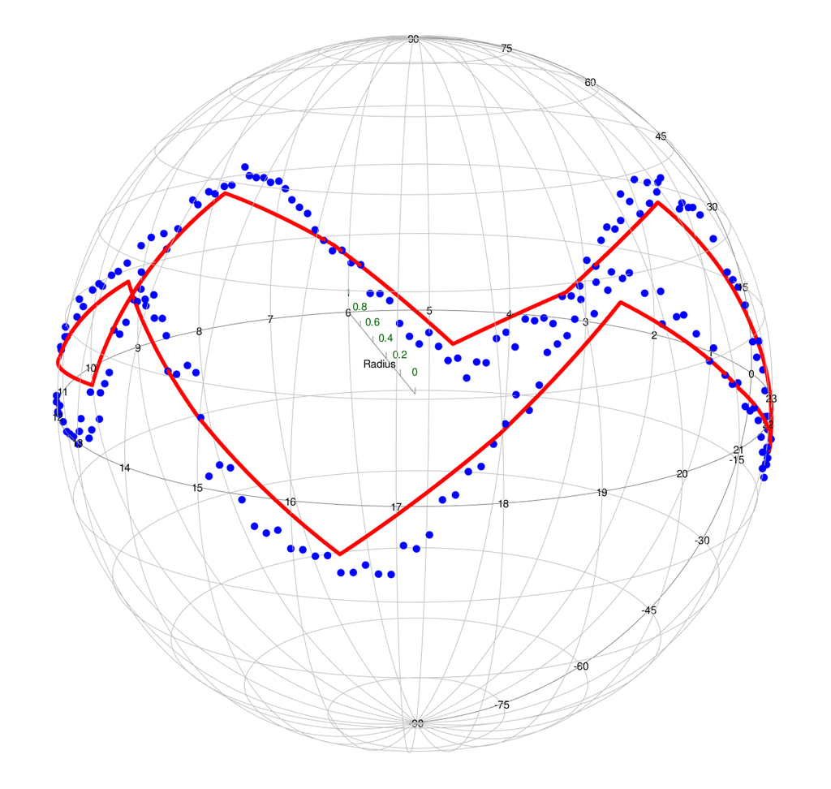

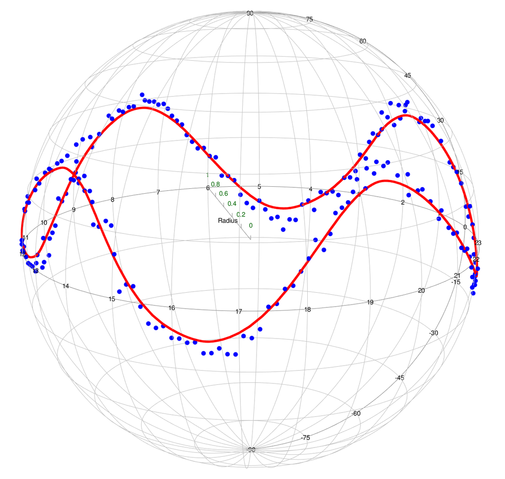

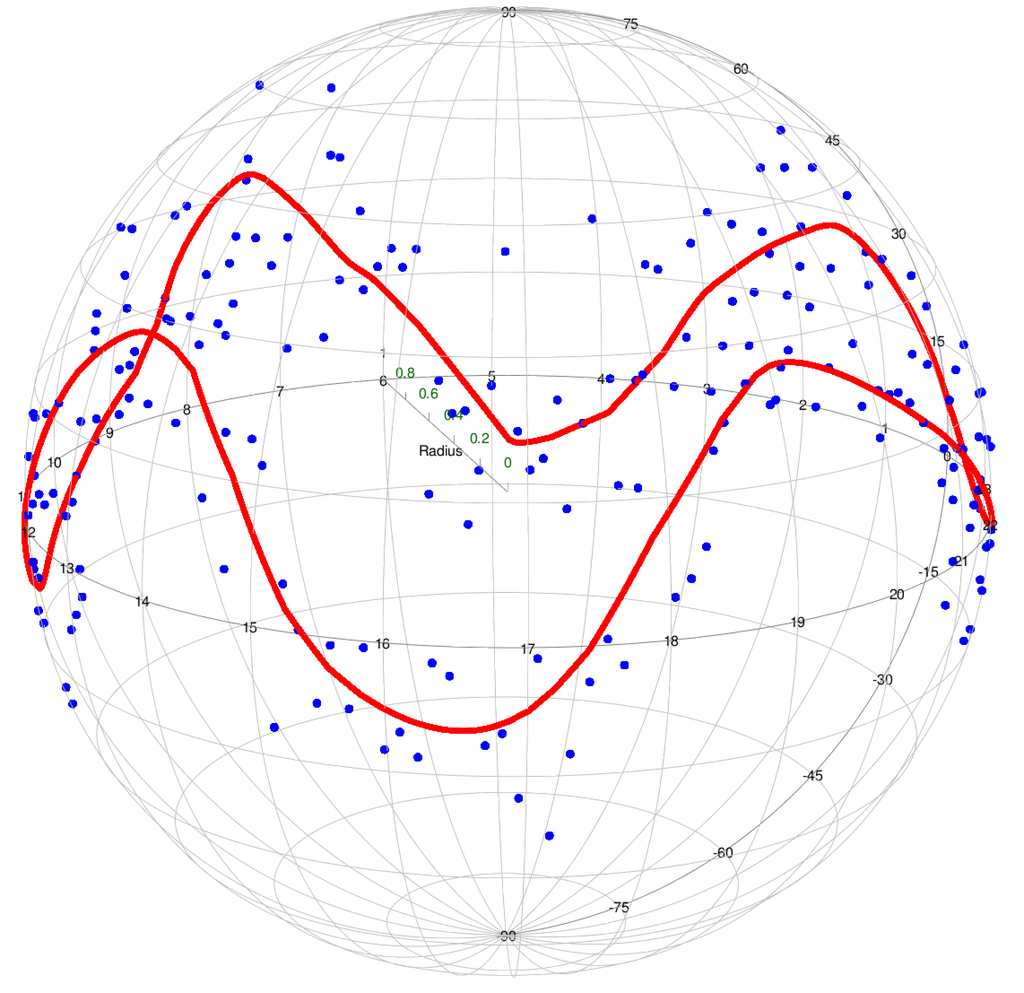

Figure 3: Left and middle: The waveform data (blue) and the results (red) of Hauberg’s principal curves (left) and spherical principal curves. Right: The noisy waveform data (blue) and the result (red) of spherical principal curves. All cases are implemented with *q* = 0.05. The two methods find the true waveform of the data well. In particular, the spherical principal curve tends to be smoother.

Table 5: Arguments of the `SPC()`.

[output not shown]

Table 6: Outputs of the `SPC()`.

| Output | Description |
| --- | --- |
| `plot` | plotting of the result in 3D graphics. |
| `prin.curves` | spatial locations (denoted by degrees) of points in the resulting principal curves. |
| `line` | connecting lines between points in `prin.curves`. |
| `converged` | whether or not the algorithm converged. |
| `iteration` | the number of iterations of the algorithm. |
| `recon.error` | sum of squared distances between the data and their projections. |
| `num.dist.pt` | the number of distinct projections. |

## Options for spherical principal curves

There are some options for the `SPC()` and `SPC.Hauberg()` functions. In particular, we implement using the arguments `plot.proj` and `deletePoints`, described in Table 5. If `plot.proj = TRUE` is used, then the projection line for each data point is plotted. If the argument `deletePoints = TRUE` is performed, the `SPC()` function deletes the points in curves that do not have adjacent data for each expectation step required to fit the principal curves, returning an open curve, *i.e.*, a curve with endpoints. As a result, the principal curves are more parsimonious since a redundant part of the resulting curves is removed. The `SPC.Hauberg()` function also contains the same options. For implementing these two arguments, the following codes are performed through real earthquake data.

```r
   > data(Earthquake)
   # collect spatial locations (longitude and latitude denoted by degrees) of data
   > earthquake <- cbind(Earthquake$longitude, Earthquake$latitude)

   #### example 1: plot the projection lines (option of plot.proj)
   > SPC(earthquake, q = 0.1, plot.proj = TRUE)

   #### example 2: open principal curves (option of deletePoints)
   > SPC(earthquake, q = 0.04, deletePoints = TRUE)
```

The results are illustrated in Figure 4. The left panel shows a closed principal curve (red) with projection lines (black) of each data point onto the curve, and the right panel displays an open principal curve due to the option `deletePoints = TRUE`. It is a parsimonious result because the redundant part on the upper right side of the sphere is removed.

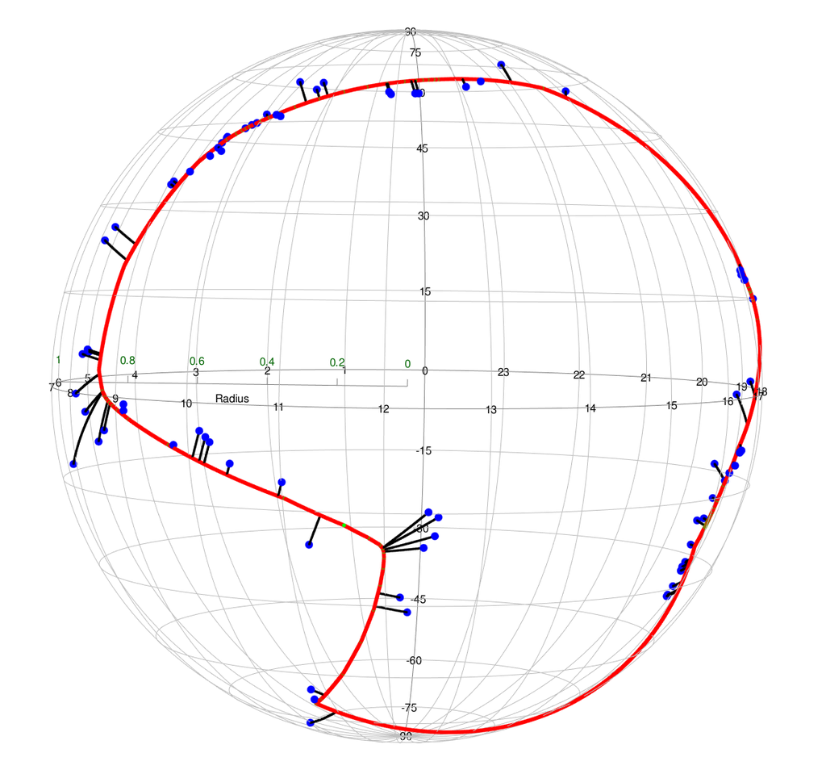

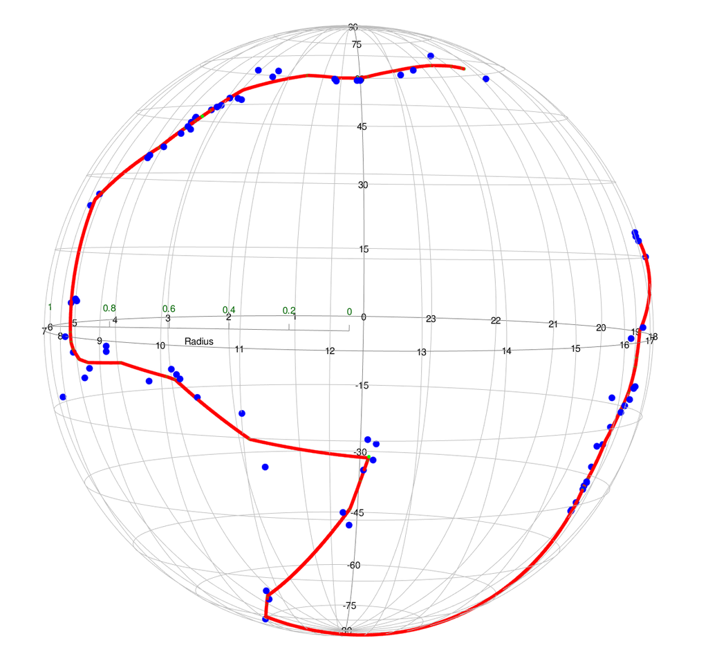

Figure 4: Left: Projection result (black) of SPC with *q* = 0.1. The spherical principal curve (red) continuously represents the earthquake data (blue). Right: The open curve of SPC with *q* = 0.04 and `deletePoints=TRUE`. The less *q* is, the more the curve overfits the data.

# Local principal geodesics

Suppose that observations have a non-geodesic structure. Then the PGA may not be beneficial to represent such data because PGA always results in a geodesic line. To overcome this problem, we consider performing PGA locally and repeatedly to detect the non-geodesic and complex structures of data, which can be interpreted as a localized version of the PGA and SPC. The newly proposed method is called local principal geodesics (LPG). The main idea behind the LPG is that non-geodesic structures can be regarded as a part of geodesic when viewed locally. Although there is no reference to the LPG because research on LPG is underway, there is a localized principal curve method on Euclidean space (Einbeck, Tutz, and Evers 2005), which is similar to LPG and may share some motivation with the LPG. For more details, refer to (Einbeck, Tutz, and Evers 2005).

The package [*spherepc*](https://CRAN.R-project.org/package=spherepc) offers the `LPG()` function to recognize various data structures, such as spirals, zigzag, and tree data. The usage of the function is

```r
    LPG(data, scale = 0.04, tau = scale/3, nu = 0, maxpt = 500,
        seed = NULL, kernel = "indicator", thres = 1e-4, col1 = "blue",
        col2 = "green", col3 = "red").
```

Like the previous functions, before the `LPG()` function is implemented, it requires to load the [*rgl*](https://CRAN.R-project.org/package=rgl) (Adler and Murdoch 2020), [*sphereplot*](https://CRAN.R-project.org/package=sphereplot) (Robotham 2013), and [*geosphere*](https://CRAN.R-project.org/package=geosphere) (Hijmans, Williams, and Vennes 2017) packages. The detailed arguments and outputs of this function are described in Tables 7 and 8. We implement the following code to apply the `LPG()` function to the spiral, zigzag, and tree simulated data illustrated in Figures 5, 6, and 7.

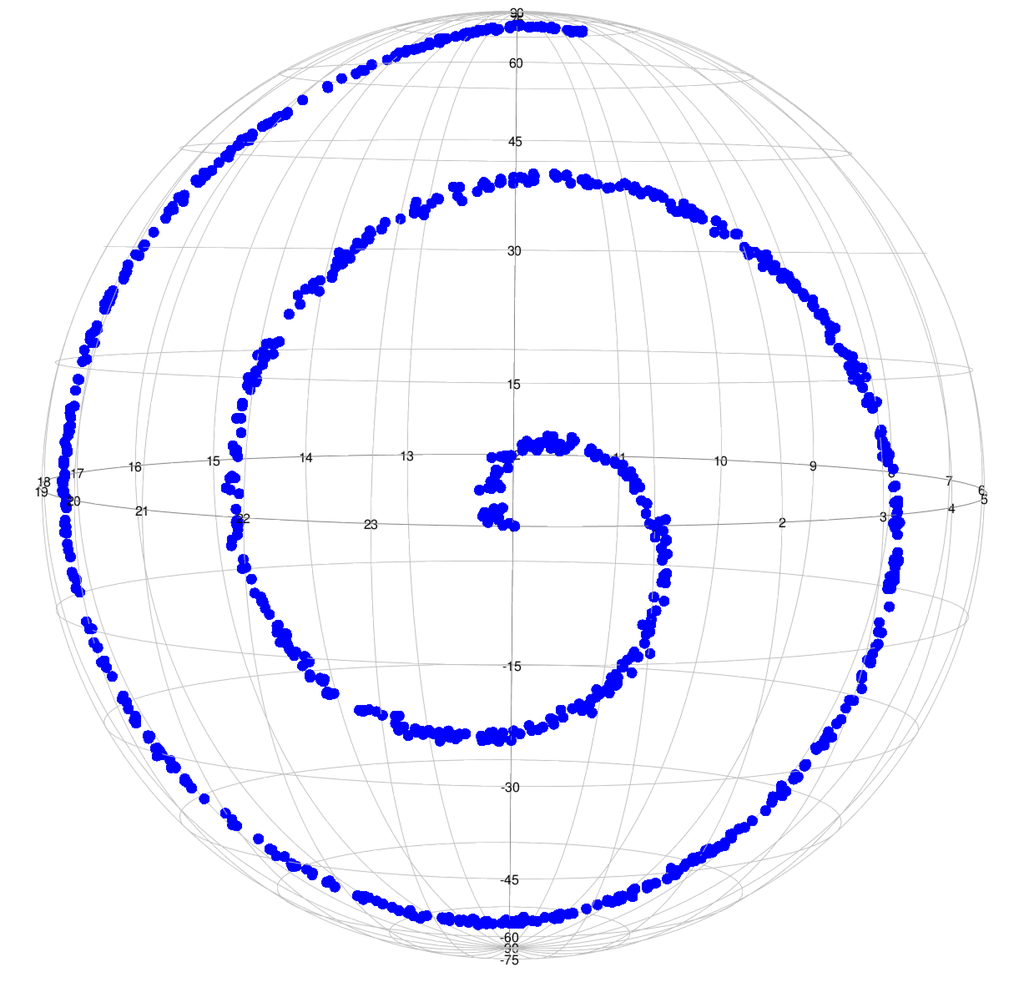

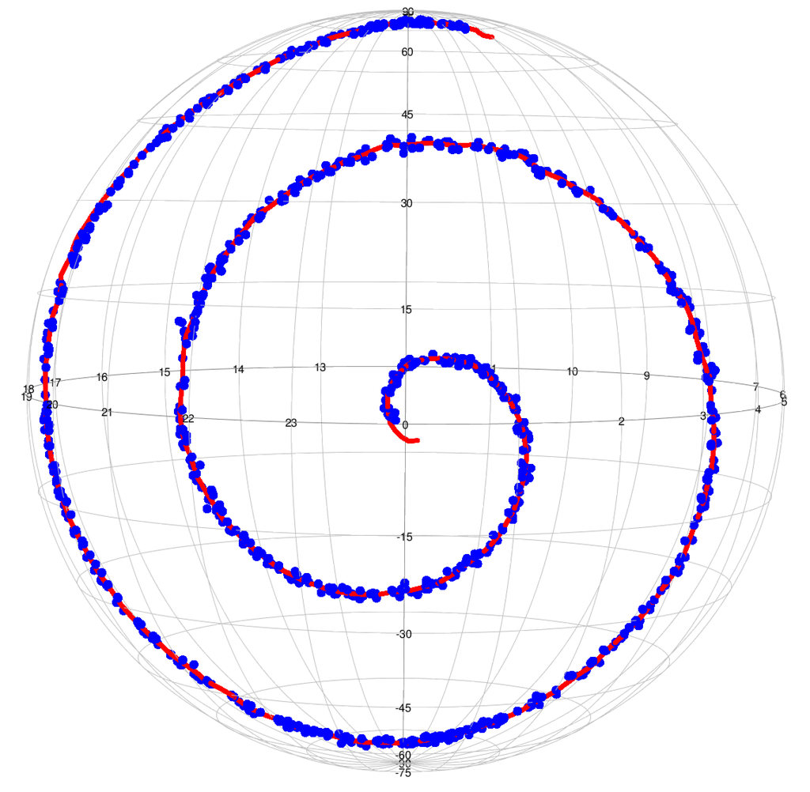

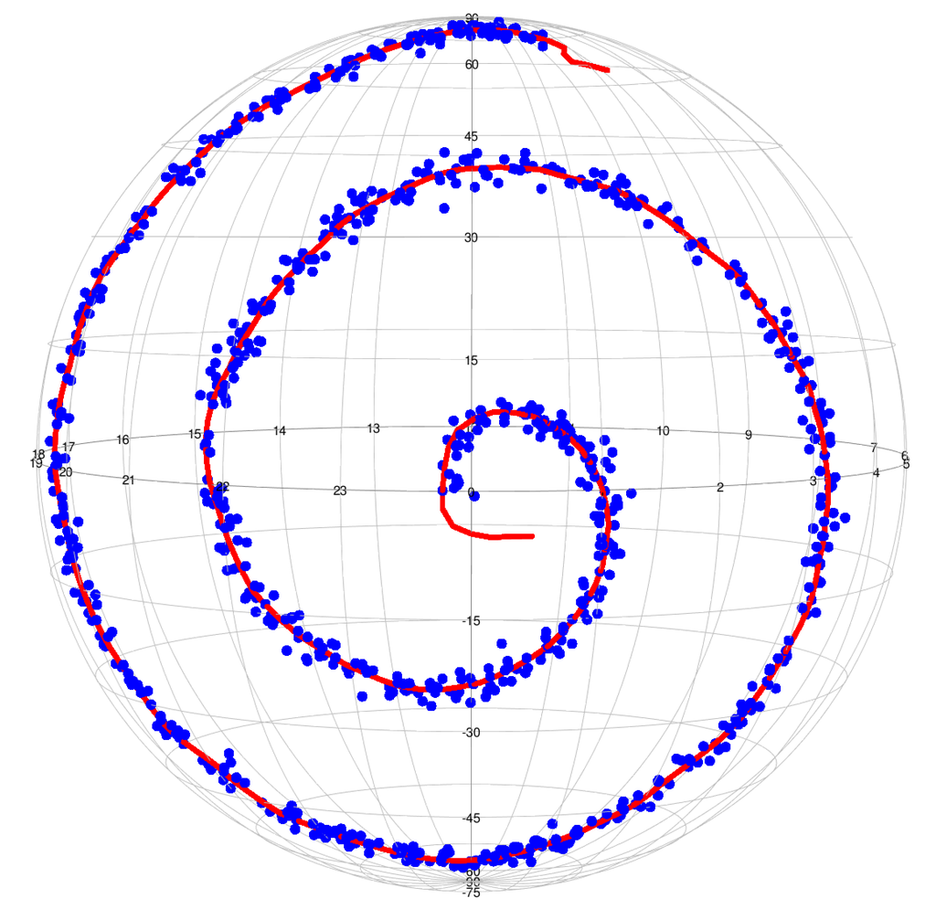

Figure 5: Left: Spiral data (blue) and the result (red) of LPG with *s**c**a**l**e* = 0.06 and *n**u* = 0.1. Right: Noisy spiral data (blue) and the result (red) of LPG with *s**c**a**l**e* = 0.12 and *n**u* = 0.1. Local principal geodesics represent the spiral patterns of the (noisy) spiral data. The larger the noise is, the larger scale is required.

```r
   ## longitude and latitude are expressed in degrees
   #### example 1: spiral data
   > set.seed(40)
   > n <- 900                                     # the number of samples
   > sigma1 <- 1; sigma2 <- 2.5;                  # noise levels
   > radius <- 73; slope <- pi/16                 # radius and slope of the spiral
   ## polar coordinate of (longitude, latitude)
   > r <- runif(n)^(2/3) * radius; theta <- -slope * r + 3
   ## transform to (longitude, latitude)
   > correction <- (0.5 * r/radius + 0.3)         # correction of noise level
   > lon1 <- r * cos(theta) + correction * sigma1 * rnorm(n)
   > lat1 <- r * sin(theta) + correction * sigma1 * rnorm(n)
   > lon2 <- r * cos(theta) + correction * sigma2 * rnorm(n)
   > lat2 <- r * sin(theta) + correction * sigma2 * rnorm(n)
   > spiral1 <- cbind(lon1, lat1); spiral2 <- cbind(lon2, lat2)
   ## plot the spiral data
   > rgl.sphgrid(col.lat = 'black', col.long = 'black')
   > rgl.sphpoints(spiral1, radius = 1, col = 'blue', size = 12)
   ## implement the LPG to (noisy) spiral data
   > LPG(spiral1, scale = 0.06, nu = 0.1, seed = 100)
   > LPG(spiral2, scale = 0.12, nu = 0.1, seed = 100)
```

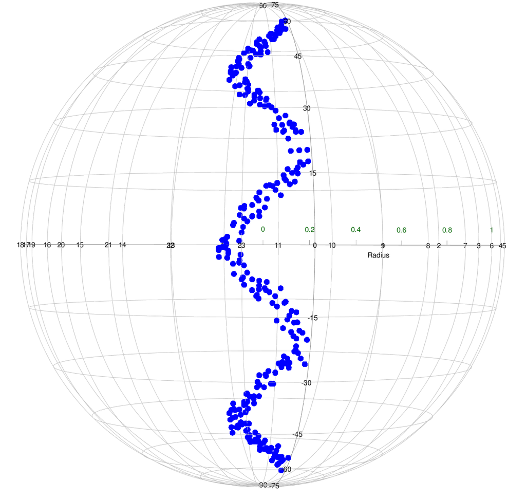

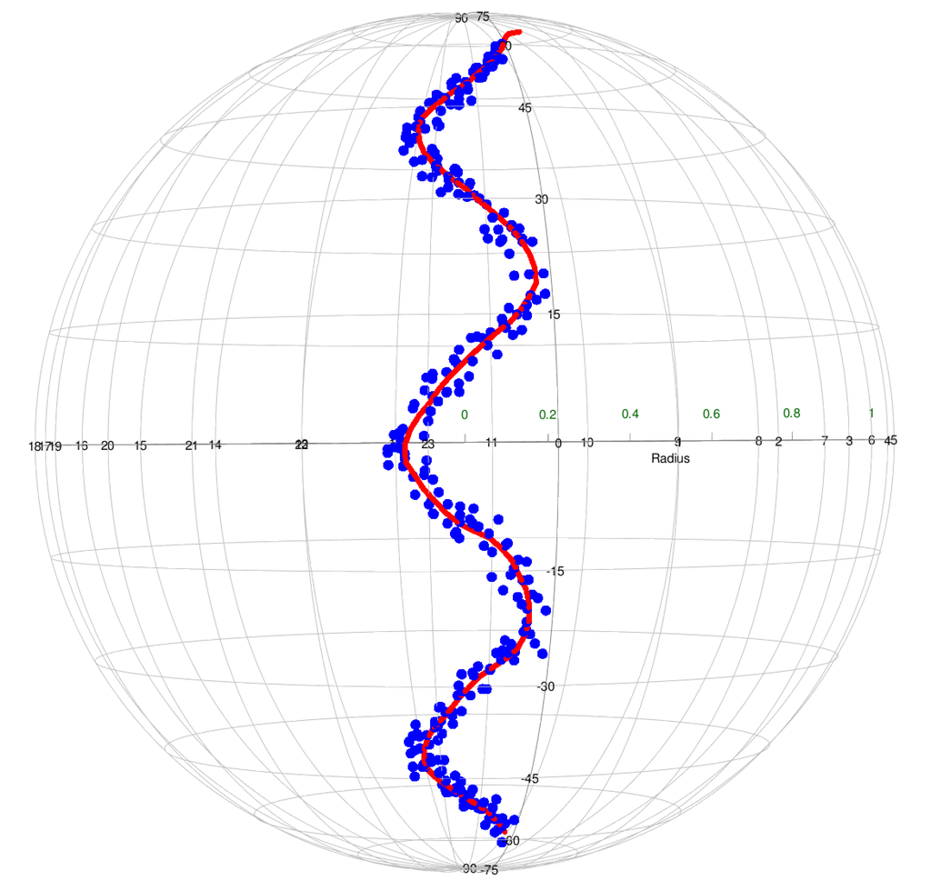

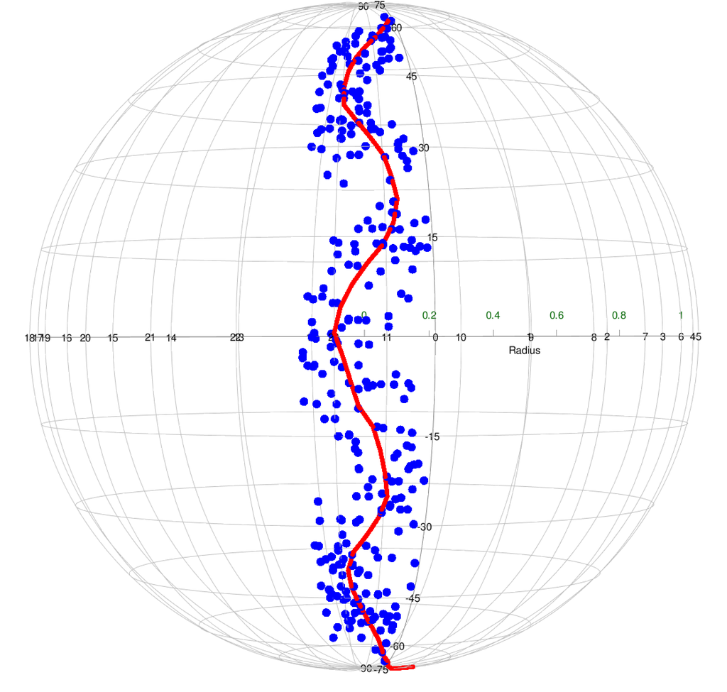

Figure 6: Left: zigzag data (blue). Middle: zigzag data (blue) and the result (red) of with *s**c**a**l**e* = 0.1 and *n**u* = 0.1. Right: Noisy zigzag data (blue) and the result (red) of LPG with *s**c**a**l**e* = 0.2, *a**n**d* *n**u* = 0.1. Local principal geodesics extract the zigzag structures of the (noisy) zigzag data properly. The larger the noise is, the larger scale is needed.

```r
   #### example 2: zigzag data
   > set.seed(10)
   > n <- 50                                # the number of samples is 6 * n = 300
   > sigma1 <- 2; sigma2 <- 5               # noise levels
   > x1 <- x2 <- x3 <- x4 <- x5 <- x6 <- runif(n) * 20 - 20
   > y1 <- x1 + 20 + sigma1 * rnorm(n); y2 <- -x2 + 20 + sigma1 * rnorm(n)
   > y3 <- x3 + 60 + sigma1 * rnorm(n); y4 <- -x4 - 20 + sigma1 * rnorm(n)
   > y5 <- x5 - 20 + sigma1 * rnorm(n); y6 <- -x6 - 60 + sigma1 * rnorm(n)
   > x <- c(x1, x2, x3, x4, x5, x6); y <- c(y1, y2, y3, y4, y5, y6)
   > simul.zigzag1 <- cbind(x, y)
   ## plot the zigzag data
   > sphereplot::rgl.sphgrid(col.lat = 'black', col.long = 'black')
   > sphereplot::rgl.sphpoints(simul.zigzag1, radius = 1, col = 'blue', size = 12)
   ## implement the LPG to the zigzag data
   > LPG(simul.zigzag1, scale = 0.1, nu = 0.1, maxpt = 45, seed = 50)

   ## noisy zigzag data
   > set.seed(10)
   > z1 <- z2 <- z3 <- z4 <- z5 <- z6 <- runif(n) * 20 - 20
   > w1 <- z1 + 20 + sigma2 * rnorm(n); w2 <- -z2 + 20 + sigma2 * rnorm(n)
   > w3 <- z3 + 60 + sigma2 * rnorm(n); w4 <- -z4 - 20 + sigma2 * rnorm(n)
   > w5 <- z5 - 20 + sigma2 * rnorm(n); w6 <- -z6 - 60 + sigma2 * rnorm(n)
   > z <- c(z1, z2, z3, z4, z5, z6); w <- c(w1, w2, w3, w4, w5, w6)
   > simul.zigzag2 <- cbind(z, w)
   ## implement the LPG to the noisy zigzag data
   > LPG(simul.zigzag2, scale = 0.2, nu = 0.1, maxpt = 18, seed = 20)
```

Note that the `LPG()` function may return several curves. We now implement the function in a complex simulation dataset composed of several curves. As shown in the left panel of Figure 7, the tree object has twenty-six geodesic (linear) structures consisting of one stem, five branches, and twenty subbranches. It is not informative to show the generating formula for the tree dataset. Instead, we provide its generating code with explanatory notes as follows.

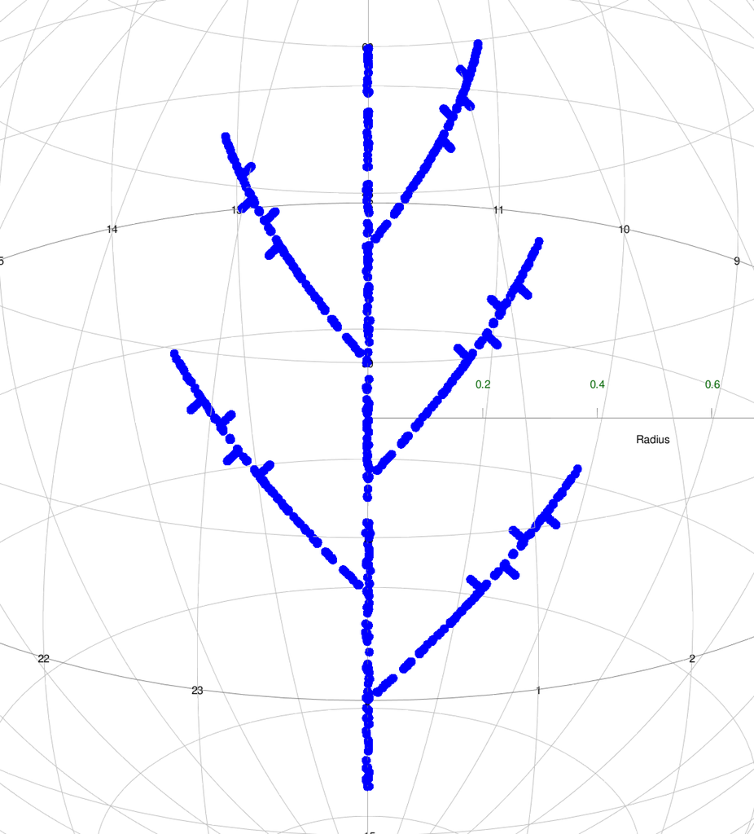

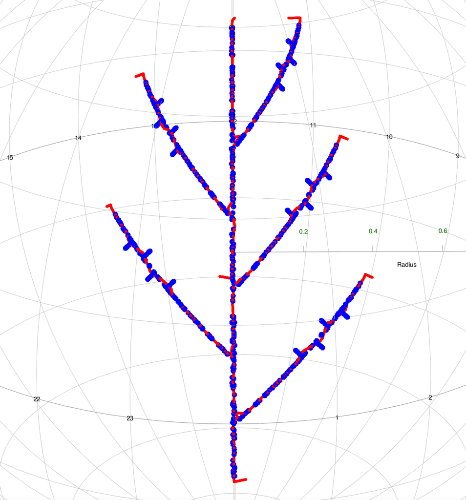

Figure 7: Tree data (blue) and the result (red) of LPG with *s**c**a**l**e* = 0.03 and =0.2. The LPG function captures the complex structures of the data well, provided that and are properly chosen.

```r
  #### example 3: tree dataset
  ## the tree dataset consists of stem, branches and subbranches
  ## generate stem
  > set.seed(10)
  > n1 <- 200; n2 <- 100; n3 <- 15     # the number of samples in
                                       # a stem, a branch, and a subbrach
  > sigma1 <- 0.1; sigma2 <- 0.05; sigma3 <- 0.01          # noise levels
  > noise1 <- sigma1 * rnorm(n1); noise2 <- sigma2 * rnorm(n2)
  > noise3 <- sigma3 * rnorm(n3)
  > l1 <- 70; l2 <- 20; l3 <- 1        # length of stem, branches, and subbranches
  > rep1 <- l1 * runif(n1)             # repeated part of stem
  > stem <- cbind(0 + noise1, rep1 - 10)
  ## generate branch
  > rep2 <- l2 * runif(n2)             # repeated part of branch
  > branch1 <- cbind(-rep2, rep2 + 10 + noise2); branch2 <- cbind(rep2, rep2 + noise2)
  > branch3 <- cbind(rep2, rep2 + 20 + noise2)
  > branch4 <- cbind(rep2, rep2 + 40 + noise2)
  > branch5 <- cbind(-rep2, rep2 + 30 + noise2)
  > branch <- rbind(branch1, branch2, branch3, branch4, branch5)
  ## generate subbranches
  > rep3 <- l3 * runif(n3)             # repeated part in subbranches
  > branches1 <- cbind(rep3 - 10, rep3 + 20 + noise3)
  > branches2 <- cbind(-rep3 + 10, rep3 + 10 + noise3)
  > branches3 <- cbind(rep3 - 14, rep3 + 24 + noise3)
  > branches4 <- cbind(-rep3 + 14, rep3 + 14 + noise3)
  > branches5 <- cbind(-rep3 - 12, -rep3 + 22 + noise3)
  > branches6 <- cbind(rep3 + 12, -rep3 + 12 + noise3)
  > branches7 <- cbind(-rep3 - 16, -rep3 + 26 + noise3)
  > branches8 <- cbind(rep3 + 16, -rep3 + 16 + noise3)
  > branches9 <- cbind(rep3 + 10, -rep3 + 50 + noise3)
  > branches10 <- cbind(-rep3 - 10, -rep3 + 40 + noise3)
  > branches11 <- cbind(-rep3 + 12, rep3 + 52 + noise3)
  > branches12 <- cbind(rep3 - 12, rep3 + 42 + noise3)
  > branches13 <- cbind(rep3 + 14, -rep3 + 54 + noise3)
  > branches14 <- cbind(-rep3 - 14, -rep3 + 44 + noise3)
  > branches15 <- cbind(-rep3 + 16, rep3 + 56 + noise3)
  > branches16 <- cbind(rep3 - 16, rep3 + 46 + noise3)
  > branches17 <- cbind(-rep3 + 10, rep3 + 30 + noise3)
  > branches18 <- cbind(-rep3 + 14, rep3 + 34 + noise3)
  > branches19 <- cbind(rep3 + 16, -rep3 + 36 + noise3)
  > branches20 <- cbind(rep3 + 12, -rep3 + 32 + noise3)
  > sub.branches <- rbind(branches1, branches2, branches3, branches4, branches5,
  + branches6, branches7, branches8, branches9, branches10, branches11, branches12,
  + branches13, branches14, branches15, branches16, branches17, branches18,
  + branches19, branches20)
  ## tree dataset consists of stem, branch, and subbranches
  > tree <- rbind(stem, branch, sub.branches)
  ## plot the tree dataset
  > sphereplot::rgl.sphgrid(col.lat = 'black', col.long = 'black')
  > sphereplot::rgl.sphpoints(tree, radius = 1, col = 'blue', size = 12)
  ## implement the LPG function to the tree dataset
  > LPG(tree, scale = 0.03, nu = 0.2, seed = 10)
```

As displayed in Figures 5, 6, and 7, the `LPG()` function identifies the non-geodesic or complex patterns of the simulated datasets well as long as the parameters of $scale~and~nu$ are properly chosen. The arguments and outputs of the function are respectively described in Tables 7 and 8.

Table 7: Arguments of the `LPG()`.

| Argument | Description |
| --- | --- |
| `data` | matrix or data frame consisting of spatial locations with two columns. Each row represents longitude and latitude (denoted by degrees). |
| `scale` | scale parameter for this function. The argument is the degree to which the `LPG` function expresses data locally; thus, as the `scale` grows, the result of the `LPG` becomes similar to that of the `PG… |
| `tau` | forwarding or backwarding distance of each step. It is empirically recommended to choose a third of `scale`, which is the default of this argument. |
| `nu` | parameter to alleviate bias of resulting curves. `nu` represents the viscosity of the given data and it should be selected in $[0,\, 1)$. The default is zero. When `nu` is close to 1, the curve usuall… |
| `maxpt` | maximum number of points in each curve. The default is 500. |
| `seed` | random seed number. |
| `kernel` | kind of kernel function. The default is the indicator kernel, and the alternative is quartic or Gaussian. |
| `thres` | threshold of the stopping condition for the `IntrinsicMean` function in the process of the `LPG` function. The default is 1e-4. |
| `col1` | color of data. The default is blue. |
| `col2` | color of points in the resulting principal curves. The default is green. |
| `col3` | color of the resulting curves. The default is red. |

Table 8: Outputs of the `LPG()`.

| Output | Description |
| --- | --- |
| `plot` | plotting of the result in 3D graphics. |
| `num.curves` | the number of resulting curves. |
| `prin.curves` | spatial locations (represented by degrees) of points in the resulting curves. |
| `line` | connecting lines between points in `prin.curves`. |

# Application

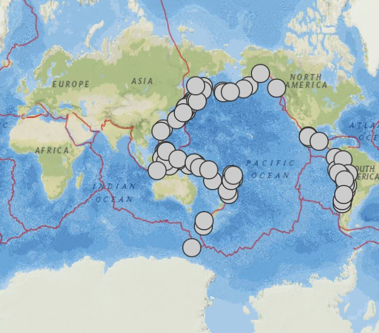

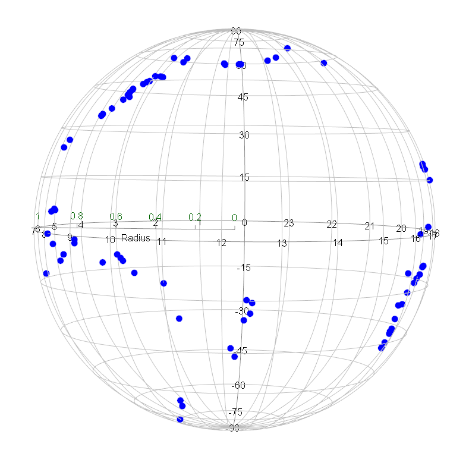

Figure 8: The distribution of significant earthquakes (8+ Mb magnitude), and their three-dimensional visualization.

We use earthquake data from the U.S. Geological Survey, which has collected significant earthquakes (8+ Mb magnitude) around the Pacific Ocean since 1900. As shown in Figure 8, the data contain 77 observations distributed in the borders between the Eurasian, Pacific, North American, and Nazca tectonic plates. The data have three features: the observations are distributed globally, scattered, and form non-geodesic structures. Because the tectonic plates are constantly moving in different directions, identifying the hidden patterns of borders is useful in geostatistics and seismology, as noted in (Biau and Fischer 2011; Mardia 2014). It can be possible to identify the borders of plates by applying dimension reduction methods to the earthquake data.

To apply the aforementioned dimension reduction methods to the earthquake data, we use the following code.

```r
   > data(Earthquake)
   #### collect spatial locations (longitude and latitude by degrees) of data
   > earthquake <- cbind(Earthquake$longitude, Earthquake$latitude)

   #### example 1: principal geodesic analysis (PGA)
   > PGA(earthquake)

   #### example 2: principal circle
   ## get center and radius of principal circle
   > circle <- PrincipalCircle(earthquake)
   ## generate the principal circle
   > PC <- GenerateCircle(circle[1:2], circle[3], T = 1000)
   ## plot the principal circle
   > sphereplot::rgl.sphgrid(col.long = "black", col.lat = "black")
   > sphereplot::rgl.sphpoints(earthquake, radius = 1, col = "blue", size = 12)
   > sphereplot::rgl.sphpoints(PC, radius = 1, col = "red", size = 9)
```

Examples 1 and 2 implement the principal geodesic and the principal circle, respectively. As illustrated in Figure 9, the principal geodesic (left) fails to identify the variations of the earthquake data. The principal circle (right) captures the global trend of the data, whereas the circle could not extract the local variations of the data.

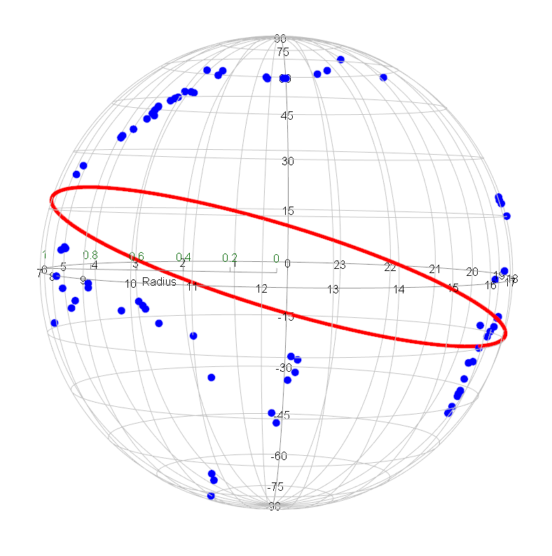

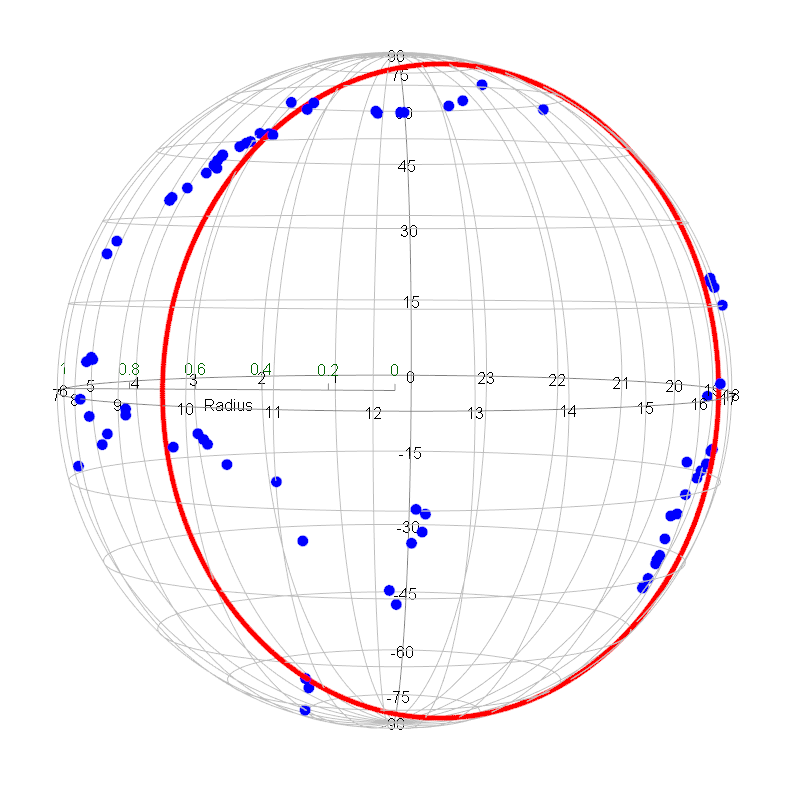

Figure 9: Earthquake data (blue) and the results (red) of the principal geodesic analysis and principal circle, from left to right. The principal geodesic fails to find the non-geodesic feature of the data, and the principal circle captures the circular pattern but cannot identify the local variations of the data.

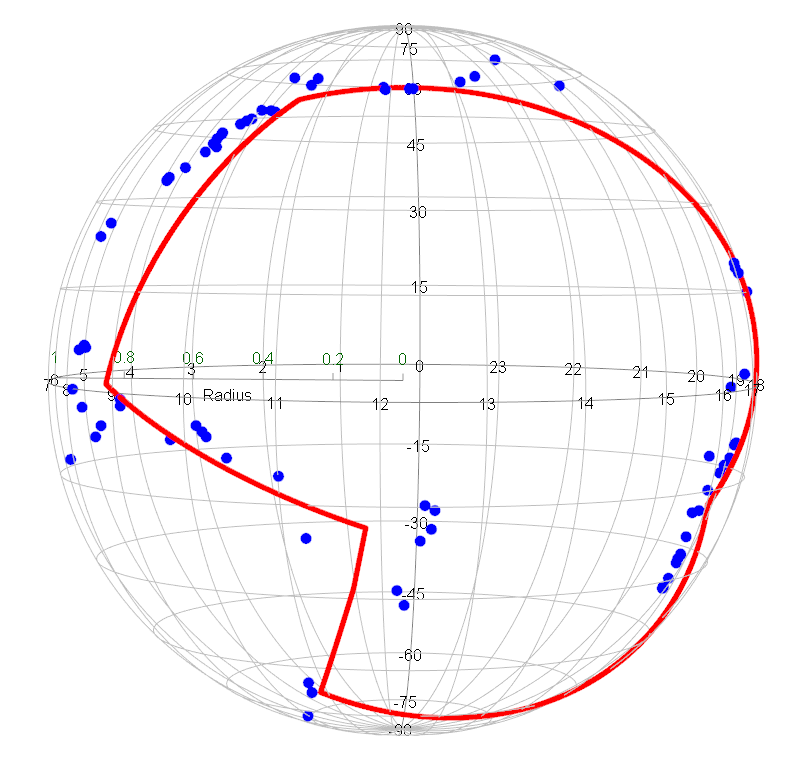

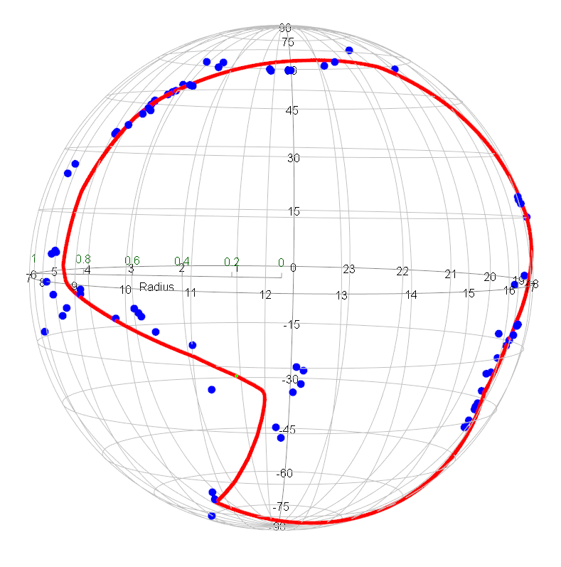

Figure 10: Earthquake data (blue) and implementation results (red) with *q* = 0.1 of the SPC.Hauberg and SPC functions, respectively, from left to right. Both methods can represent the non-geodesic feature of the earthquake data. The spherical principal curve particularly tends to be smoother.

```r
   #### example 3: spherical principal curves and principal curves of Hauberg
   > SPC.Hauberg(earthquake, q = 0.1) # principal curves of Hauberg
   > SPC(earthquake, q = 0.1)         # spherical principal curves
```

Example 3 fits the spherical principal curve and Hauberg’s principal curve with $q=0.1$. As shown in Figure 10, both methods identify the curved feature of the earthquake data. The spherical principal curve particularly tends to be more continuous than Hauberg’s principal curve.

```r
   #### example 4: spherical principal curves with q = 0.15, 0.1, 0.03, and 0.02
   > SPC(earthquake, q = 0.15)
   > SPC(earthquake, q = 0.1)
   > SPC(earthquake, q = 0.03)
   > SPC(earthquake, q = 0.02)
```

Example 4 applies the spherical principal curve to the earthquake data with varying $q=0.15,\, 0.1,\, 0.03,\, 0.02$. The parameter $q$ plays a role in the bandwidth of the `SPC()` function. As shown in Figure 11, the smaller $q$ is, the rougher the curve is. On the contrary, the larger $q$ is, the smoother the curve is.

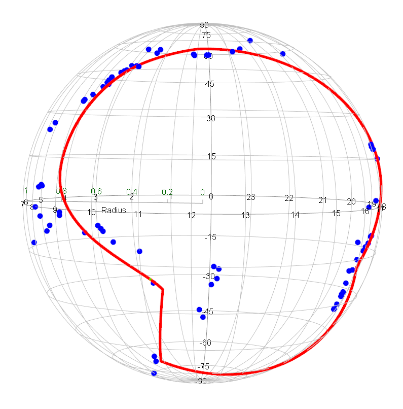

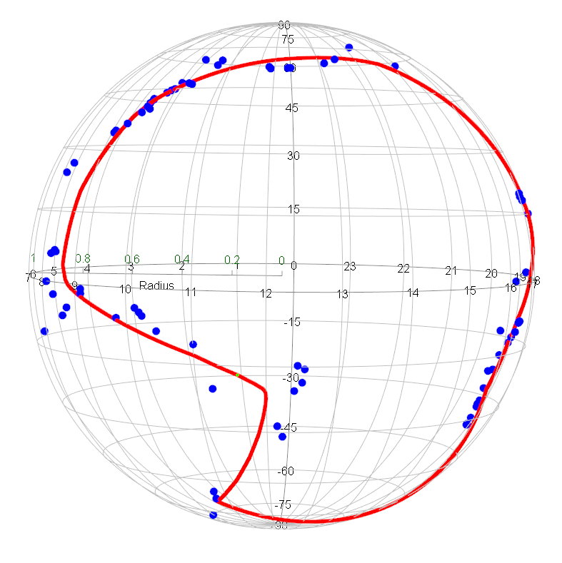

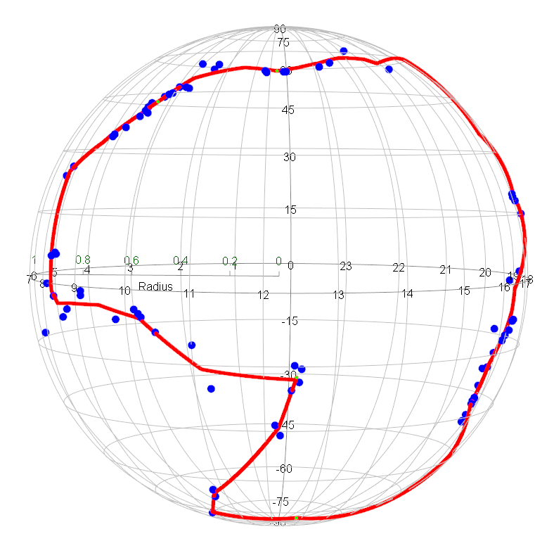

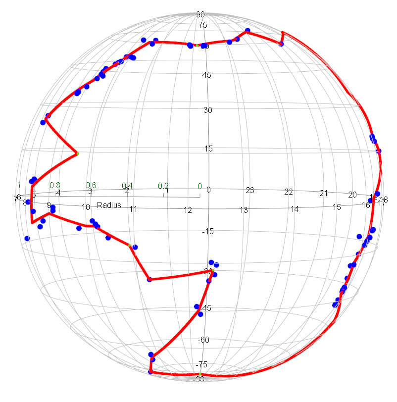

Figure 11: From left to right and top to bottom: Earthquake data (blue) and the results (red) of the SPC with *q* = 0.15, 0.1, 0.03 *a**n**d* 0.02. The larger the parameter *q* is, the smoother the curve is, while it tends to underfit the data. Conversely, the smaller the parameter *q* is, the rougher the curve is.

```r
   #### example 5: local principal geodesics (LPG)
   > LPG(earthquake, scale = 0.5, nu = 0.2, maxpt = 20, seed = 50)
   > LPG(earthquake, scale = 0.4, nu = 0.3, maxpt = 22, seed = 50)
```

Lastly, example 5 implements the `LPG()` function with different `scale` and `nu`. As shown in Figure 12, the function represents the curved pattern of the data, illustrating the slightly different features.

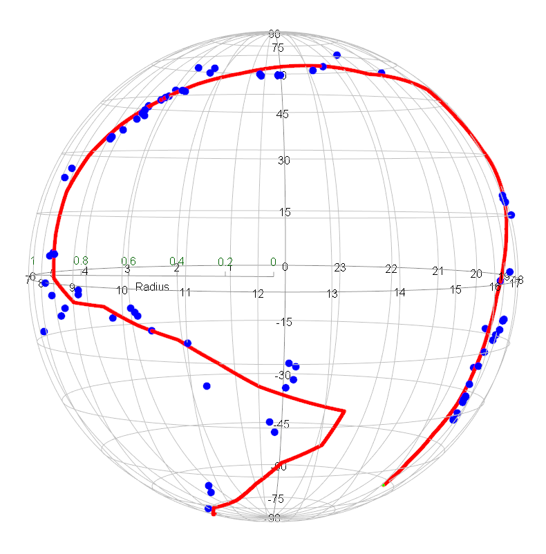

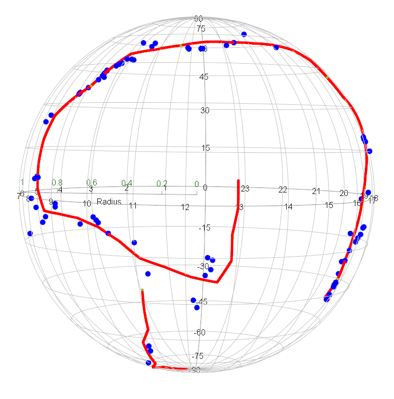

Figure 12: From left to right, earthquake data (blue) and the results of the LPG function with *s**c**a**l**e* = 0.5, nu=0.2 and *s**c**a**l**e* = 0.4, nu=0.3. Both the local principal geodesics implemented by different parameters recognize the non-geodesic and scattered pattern of the data, illustrating the different features.

# Conclusions

In this paper, the R package [*spherepc*](https://CRAN.R-project.org/package=spherepc) has implemented various dimension reduction methods on a sphere. It includes not only principal geodesic analysis (PGA), principal circle, and principal curves of Hauberg (2016) as existing methods but also spherical principal curves (SPC) and local principal geodesics (LPG) as new approaches. The [*spherepc*](https://CRAN.R-project.org/package=spherepc) package has demonstrated its usefulness by applying the functions to several simulation examples and real earthquake data. We believe that the [*spherepc*](https://CRAN.R-project.org/package=spherepc) is helpful for applications in various fields, ranging from statistics to engineering, such as geostatistics, image analysis, pattern recognition, and machine learning.

# Acknowledgments

This research was supported by the National Research Foundation of Korea (NRF) funded by the Korea government (2020R1A4A1018207; 2021R1A2C1091357).

Adler, Daniel, and Duncan Murdoch. 2020. **Rgl**: 3D Visualization Using OpenGL. https://cran.r-project.org/package=rgl.

Benner, Peter, Volker Mehrmann, and Danny C Sorensen. 2005. *Dimension Reduction of Large-Scale Systems*. Vol. 45. Springer.

Biau, Gérard, and Aurélie Fischer. 2011. “Parameter Selection for Principal Curves.” *IEEE Transactions on Information Theory* 58 (3): 1924–39.

Einbeck, Jochen, Ludger Evers, and Maintainer Jochen Einbeck. 2015. **LPCM**: Local Principal Curve Method. https://cran.r-project.org/package=LPCM.

Einbeck, Jochen, Gerhard Tutz, and Ludger Evers. 2005. “Local Principal Curves.” *Statistics and Computing* 15 (4): 301–13.

Fletcher, P Thomas, Conglin Lu, Stephen M Pizer, and Sarang Joshi. 2004. “Principal Geodesic Analysis for the Study of Nonlinear Statistics of Shape.” *IEEE Transactions on Medical Imaging* 23 (8): 995–1005.

Hastie, Trevor, and Werner Stuetzle. 1989. “Principal Curves.” *Journal of the American Statistical Association* 84 (406): 502–16.

Hastie, Trevor, and Andreas Weingessel. 2015. **Princurve**: Fits a Principal Curve in Arbitrary Dimension. https://cran.r-project.org/package=princurve.

Hauberg, S. 2016. “Principal Curves on Riemannian Manifolds.” *IEEE Transactions on Pattern Analysis and Machine Intelligence* 38 (9): 1915.

Hijmans, Robert J, Ed Williams, and Chris Vennes. 2017. **Geosphere**: Spherical Trigonometry. https://cran.r-project.org/package=geosphere.

Huckemann, Stephan, Thomas Hotz, and Axel Munk. 2010. “Intrinsic Shape Analysis: Geodesic PCA for Riemannian Manifolds Modulo Isometric Lie Group Actions.” *Statistica Sinica*, 1–58.

Kim, Jang-Hyun, Jongmin Lee, and Hee-Seok Oh. 2020. “Spherical Principal Curves.” *arXiv Preprint arXiv:2003.02578*.

Lee, Jongmin, Jang-Hyun Kim, and Hee-Seok Oh. 2021a. “Spherical Principal Curves.” *IEEE Transactions on Pattern Analysis and Machine Intelligence* 43 (6): 2165–71.

———. 2021b. “Supplementary Material for Spherical Principal Curves.” *IEEE Transactions on Pattern Analysis and Machine Intelligence*.

Liu, Hao, Zhigang Yao, Shingyu Leung, and Tony F Chan. 2017. “A Level Set Based Variational Principal Flow Method for Nonparametric Dimension Reduction on Riemannian Manifolds.” *SIAM Journal on Scientific Computing* 39 (4): A1616–46.

Mardia, Kantilal Varichand. 2014. *Statistics of Directional Data*. Academic press.

Panaretos, Victor M, Tung Pham, and Zhigang Yao. 2014. “Principal Flows.” *Journal of the American Statistical Association* 109 (505): 424–36.

Robotham, A. 2013. **Sphereplot**: Spherical Plotting. https://cran.r-project.org/package=sphereplot.